# hw1_additional

```r
library(MASS)
library(lattice)
library(latticeExtra)
library(boot)
```

```r
library(corrplot)

adv.data <- read.csv("Advertising.csv")
adv.data$X <- NULL

model.final <- lm(Sales ~ TV + Radio + TV:Radio + I(TV^2), data = adv.data)
summary(model.final)
```

```
##
## Call:
## lm(formula = Sales ~ TV + Radio + TV:Radio + I(TV^2), data = adv.data)
##
## Residuals:
##     Min      1Q  Median      3Q     Max
## -4.9949 -0.2969 -0.0066  0.3798  1.1686
##
## Coefficients:
##               Estimate Std. Error t value Pr(>|t|)
## (Intercept)  5.137e+00  1.927e-01  26.663  < 2e-16 ***
## TV           5.092e-02  2.232e-03  22.810  < 2e-16 ***
## Radio        3.516e-02  5.901e-03   5.959 1.17e-08 ***
## I(TV^2)     -1.097e-04  6.893e-06 -15.920  < 2e-16 ***
## TV:Radio     1.077e-03  3.466e-05  31.061  < 2e-16 ***
## ---
## Signif. codes:  0 '***' 0.001 '**' 0.01 '*' 0.05 '.' 0.1 ' ' 1
##
## Residual standard error: 0.6238 on 195 degrees of freedom
## Multiple R-squared:  0.986,  Adjusted R-squared:  0.9857
## F-statistic:  3432 on 4 and 195 DF,  p-value: < 2.2e-16
```

```r
model.final
```

```
##
## Call:
## lm(formula = Sales ~ TV + Radio + TV:Radio + I(TV^2), data = adv.data)
##
## Coefficients:
## (Intercept)           TV        Radio      I(TV^2)     TV:Radio
##   5.1370622    0.0509203    0.0351623   -0.0001097    0.0010766
```

Bootstrap на model.final

```r
bs <- function(formula, data, indices) {
  d <- data[indices,]
  fit <- lm(formula, data=d)
  return(coef(fit))
}
b.model.final <- boot(data=adv.data, statistic=bs,
    R=1000, formula=Sales ~ TV + Radio + TV:Radio + I(TV^2))

b.model.final
```

```
##
## ORDINARY NONPARAMETRIC BOOTSTRAP
##
##
## Call:
## boot(data = adv.data, statistic = bs, R = 1000, formula = Sales ~
##     TV + Radio + TV:Radio + I(TV^2))
##
##
## Bootstrap Statistics :
##          original        bias     std. error
## t1*  5.1370622378  2.210665e-02 2.413939e-01
## t2*  0.0509203256 -1.634419e-04 3.217857e-03
## t3*  0.0351623365 -5.786600e-04 9.126354e-03
## t4* -0.0001097447  1.296482e-07 1.062273e-05
## t5*  0.0010766072  2.860879e-06 4.776437e-05
```

Протестируем на нормальность полученные результаты:

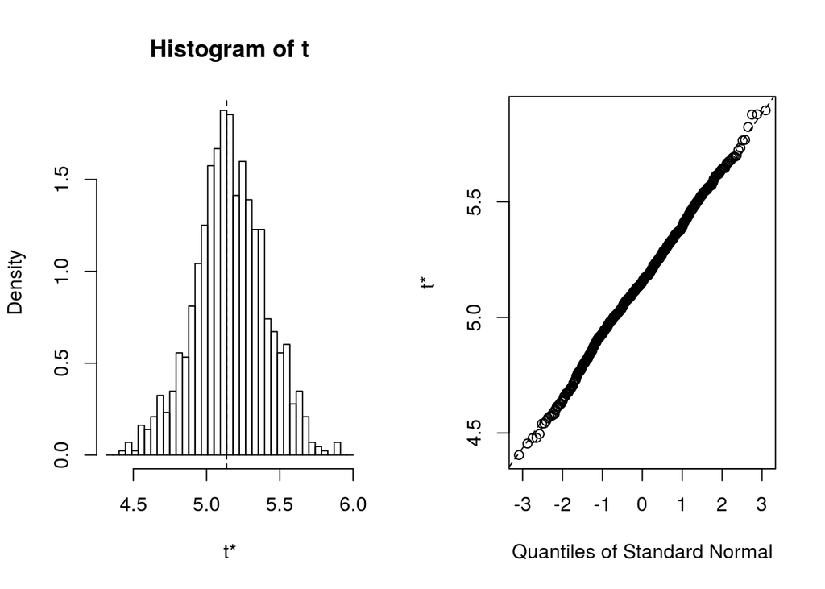

```r
plot(b.model.final, index=1) # intercept
```

```r
shapiro.test(b.model.final$t[,1])
```

```
##
##  Shapiro-Wilk normality test
##
## data:  b.model.final$t[, 1]
## W = 0.9978, p-value = 0.2098
```

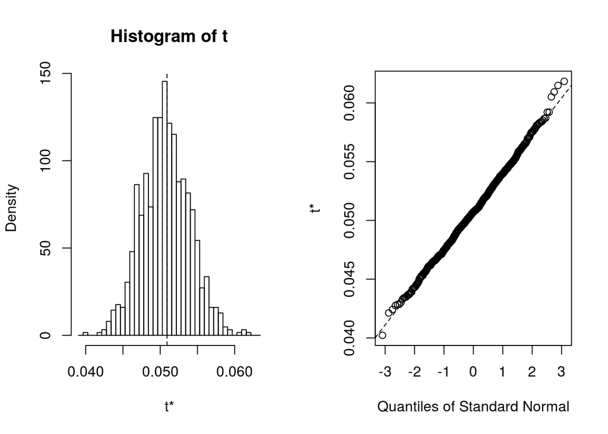

```r
plot(b.model.final, index=2) # TV
```

```r
shapiro.test(b.model.final$t[,2])
```

```
##
##  Shapiro-Wilk normality test
##
## data:  b.model.final$t[, 2]
## W = 0.9984, p-value = 0.5203
```

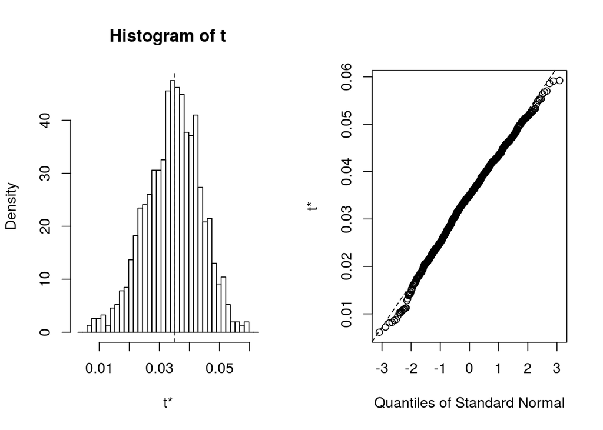

```r
plot(b.model.final, index=3) # Radio
```

```r
shapiro.test(b.model.final$t[,3])
```

```
##
##  Shapiro-Wilk normality test
##
## data:  b.model.final$t[, 3]
## W = 0.995, p-value = 0.002192
```

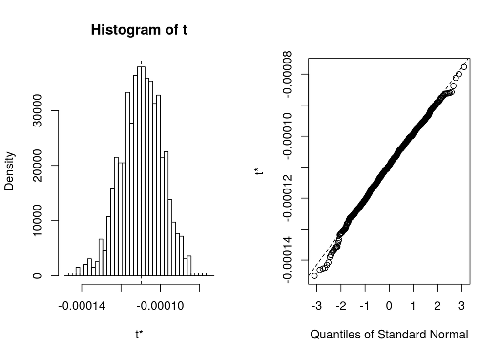

```r
plot(b.model.final, index=4) # I(TV^2)
```

```r
shapiro.test(b.model.final$t[,4])
```

```
##
##  Shapiro-Wilk normality test
##
## data:  b.model.final$t[, 4]
## W = 0.9967, p-value = 0.03751
```

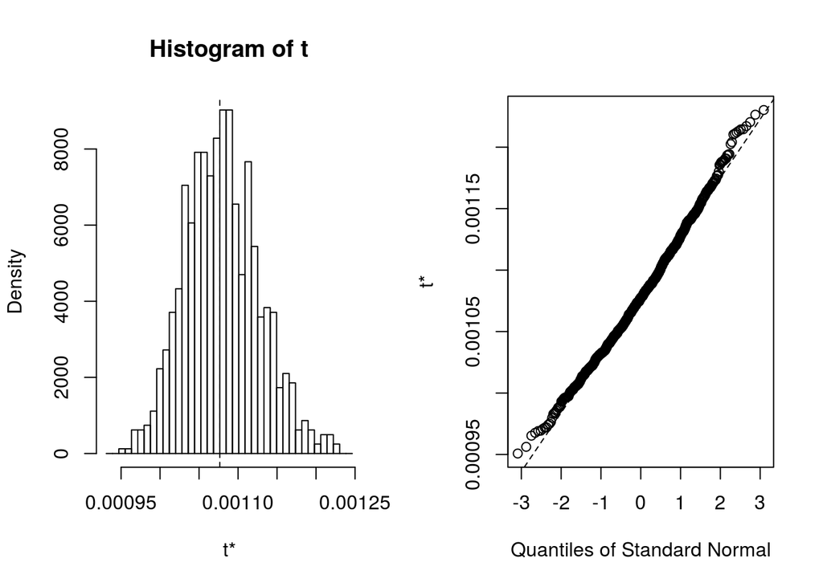

```r
plot(b.model.final, index=5) # TV:Radio
```

```r
shapiro.test(b.model.final$t[,5])
```

```
##
##  Shapiro-Wilk normality test
##
## data:  b.model.final$t[, 5]
## W = 0.9942, p-value = 0.0006829
```

Здесь и по графикам видно, и тест выдал результаты, по которым можно отвергнуть 0-ю гиботезу о том, что распределение является нормальным (p-value <= 0.05) с уровнем значимости 0.05 значит будем строить перцентильные доверительные интервалы для этих предикторов

Строим доверительные интервалы для предикторов:

```r
boot.ci(b.model.final, index=1) # intercept
```

```
## BOOTSTRAP CONFIDENCE INTERVAL CALCULATIONS
## Based on 1000 bootstrap replicates
##
## CALL :
## boot.ci(boot.out = b.model.final, index = 1)
##
## Intervals :
## Level      Normal              Basic
## 95%   ( 4.642,  5.588 )   ( 4.641,  5.616 )
##
## Level     Percentile            BCa
## 95%   ( 4.658,  5.633 )   ( 4.546,  5.550 )
## Calculations and Intervals on Original Scale
## Some BCa intervals may be unstable
```

Для intercept доверительный интервал уровня доверия 0.95 самым узким является Normal. Т.к. мы можем выбирать для этого предиктора параметрический интервал, то возьмем его.

```r
boot.ci(b.model.final, index=2) # TV
```

```
## BOOTSTRAP CONFIDENCE INTERVAL CALCULATIONS
## Based on 1000 bootstrap replicates
##
## CALL :
## boot.ci(boot.out = b.model.final, index = 2)
##
## Intervals :
## Level      Normal              Basic
## 95%   ( 0.0448,  0.0574 )   ( 0.0444,  0.0574 )
##
## Level     Percentile            BCa
## 95%   ( 0.0445,  0.0575 )   ( 0.0458,  0.0587 )
## Calculations and Intervals on Original Scale
## Some BCa intervals may be unstable
```

Для TV аналогично выбираем Normal

```r
boot.ci(b.model.final, type="perc", index=3) # Radio
```

```
## BOOTSTRAP CONFIDENCE INTERVAL CALCULATIONS
## Based on 1000 bootstrap replicates
##
## CALL :
## boot.ci(boot.out = b.model.final, type = "perc", index = 3)
##
## Intervals :
## Level     Percentile
## 95%   ( 0.0155,  0.0514 )
## Calculations and Intervals on Original Scale
```

```r
boot.ci(b.model.final, type="perc", index=4) # I(TV^2)
```

```
## BOOTSTRAP CONFIDENCE INTERVAL CALCULATIONS
## Based on 1000 bootstrap replicates
##
## CALL :
## boot.ci(boot.out = b.model.final, type = "perc", index = 4)
##
## Intervals :
## Level     Percentile
## 95%   (-0.0001, -0.0001 )
## Calculations and Intervals on Original Scale
```

```r
boot.ci(b.model.final, type="perc", index=5) # TV:Radio
```

```
## BOOTSTRAP CONFIDENCE INTERVAL CALCULATIONS
## Based on 1000 bootstrap replicates
##
## CALL :
## boot.ci(boot.out = b.model.final, type = "perc", index = 5)
##
## Intervals :
## Level     Percentile
## 95%   ( 0.0010,  0.0012 )
## Calculations and Intervals on Original Scale
```

Строим доверительный интервал по model.final, а также Normal для TV intercept

```r
confint(model.final)
```

```
##                     2.5 %        97.5 %
## (Intercept)  4.7570835060  5.517041e+00
## TV           0.0465175947  5.532306e-02
## Radio        0.0235251012  4.679957e-02
## I(TV^2)     -0.0001233401 -9.614939e-05
## TV:Radio     0.0010082486  1.144966e-03
```

```r
boot.ci(b.model.final, type="norm", index=2) # TV
```

```
## BOOTSTRAP CONFIDENCE INTERVAL CALCULATIONS
## Based on 1000 bootstrap replicates
##
## CALL :
## boot.ci(boot.out = b.model.final, type = "norm", index = 2)
##
## Intervals :
## Level      Normal
## 95%   ( 0.0448,  0.0574 )
## Calculations and Intervals on Original Scale
```

```r
boot.ci(b.model.final, type="norm", index=1) # intercept
```

```
## BOOTSTRAP CONFIDENCE INTERVAL CALCULATIONS
## Based on 1000 bootstrap replicates
##
## CALL :
## boot.ci(boot.out = b.model.final, type = "norm", index = 1)
##
## Intervals :
## Level      Normal
## 95%   ( 4.642,  5.588 )
## Calculations and Intervals on Original Scale
```

Для всех предикторов получаем в случае confint(model.final) более узкие доверительные интервалы с одинаковым уровнем доверия, чем интервалы, построенные бутстрапом. К тому же для Radio I(TV^2) TV:Radio имеем только не параметрический доверительный интервал, т.е. он может быть уже точного, а значит эти интервалы намного хуже, чем confint(model.final) Т.е. лучше выбрать confint(model.final) доверительные интервалы.